# Data Science R Basics

## Sorting

The textbook for this section is available [here](https://rafalab.github.io/dsbook/r-basics.html#sorting).

**Key Points**

- The function `sort()` sorts a vector in increasing order.
- The function `order()` produces the indices needed to obtain the sorted vector, e.g. a result of 2 3 1 5 4 means the sorted vector will be produced by listing the 2nd, 3rd, 1st, 5th, and then 4th item of the original vector.
- The function `rank()` gives us the ranks of the items in the original vector.
- The function `max()` returns the largest value while `which.max()` returns the index of the largest value. The functions `min()` and `which.min()` work similarly for minimum values.

## Assessment - Sorting

1. When looking at a dataset, we may want to sort the data in an order that makes more sense for analysis. Let’s learn to do this using the `murders` dataset as an example

```r
# Access the `state` variable and store it in an object
states <- murders$state

# Sort the object alphabetically and redefine the object
states <- sort(states)

# Report the first alphabetical value
states[1]
```

```
## [1] "Alabama"
```

```r
# Access population values from the dataset and store it in pop
pop <- murders$population

# Sort the object and save it in the same object
pop <- sort(pop)

# Report the smallest population size
pop[1]
```

```
## [1] 563626
```

2. The function `order()` returns the index vector needed to sort the vector. This implies that `sort(x)` and `x[order(x)]` give the same result.

This can be useful for finding row numbers with certain properties such as “the row for the state with the smallest population”. Remember that when we extract a variable from a data frame the order of the resulting vector is the same as the order of the rows of the data frame. So for example, the entries of the vector `murders$state` are ordered in the same way as the states if you go down the rows of `murders`.

```r
# Access population from the dataset and store it in pop
pop <- murders$population

# Use the command order to find the vector of indexes that order pop and store in object ord
ord <- order(pop)

# Find the index number of the entry with the smallest population size
ord[1]
```

```
## [1] 51
```

3. We can actually perform the same operation as in the previous exercise using the function `which.min`. It basically tells us which is the minimum value.

```r
# Find the index of the smallest value for variable total
which.min(murders$total)
```

```
## [1] 46
```

```r
# Find the index of the smallest value for population
which.min(murders$population)
```

```
## [1] 51
```

4. Now we know how small the smallest state is and we know which row represents it. However, which state is it?

```r
# Define the variable i to be the index of the smallest state
i <- which.min(murders$population)

# Define variable states to hold the states
states <- murders$state

# Use the index you just defined to find the state with the smallest population
states[i]
```

```
## [1] "Wyoming"
```

5. You can create a data frame using the data.frame function.

Here is a quick example:

```r
temp <- c(35, 88, 42, 84, 81, 30)
city <- c("Beijing", "Lagos", "Paris", "Rio de Janeiro", "San Juan", "Toronto")
city_temps <- data.frame(name = city, temperature = temp)
```

```r
# Store temperatures in an object
temp <- c(35, 88, 42, 84, 81, 30)

# Store city names in an object
city <- c("Beijing", "Lagos", "Paris", "Rio de Janeiro", "San Juan", "Toronto")

# Create data frame with city names and temperature
city_temps <- data.frame(name = city, temperature = temp)

# Define a variable states to be the state names
states <- murders$state

# Define a variable ranks to determine the population size ranks
ranks <- rank(murders$population)

# Create a data frame my_df with the state name and its rank
my_df <- data.frame(name = states, rank = ranks)
```

6. This exercise is somewhat more challenging. We are going to repeat the previous exercise but this time order ``my_df` so that the states are ordered from least populous to most.

```r
# Define a variable states to be the state names from the murders data frame
states <- murders$state

# Define a variable ranks to determine the population size ranks
ranks <- rank(murders$population)

# Define a variable ind to store the indexes needed to order the population values
ind <- order(murders$population)

# Create a data frame my_df with the state name and its rank and ordered from least populous to most
my_df <- data.frame(states = states[ind], ranks = ranks[ind])
```

7. The `na_example` dataset represents a series of counts. It is included in the *dslabs* package.

You can quickly examine the object using

```r
library(dslabs)
data(na_example)
str(na_example)
```

However, when we compute the average we obtain an `NA`. You can see this by typing

```r
mean(na_example)
```

```r
# Using new dataset
library(dslabs)
data(na_example)

# Checking the structure
str(na_example)
```

```
##  int [1:1000] 2 1 3 2 1 3 1 4 3 2 ...
```

```r
# Find out the mean of the entire dataset
mean(na_example)
```

```
## [1] NA
```

```r
# Use is.na to create a logical index ind that tells which entries are NA
ind <- is.na(na_example)

# Determine how many NA ind has using the sum function
sum(ind)
```

```
## [1] 145
```

8. We previously computed the average of `na_example` using `mean(na_example)` and obtain `NA`. This is because the function `mean` returns `NA` if it encounters at least one `NA`. A common operation is therefore removing the entries that are NA and after that perform operations on the rest.

```r
# Note what we can do with the ! operator
x <- c(1, 2, 3)
ind <- c(FALSE, TRUE, FALSE)
x[!ind]
```

```
## [1] 1 3
```

```r
# Create the ind vector
library(dslabs)
data(na_example)
ind <- is.na(na_example)

# We saw that this gives an NA
mean(na_example)
```

```
## [1] NA
```

```r
# Compute the average, for entries of na_example that are not NA
mean(na_example[!ind])
```

```
## [1] 2.3
```

## Vector arithmetic

The textbook for this section is available [here](https://rafalab.github.io/dsbook/r-basics.html#vector-arithmetics).

**Key Points**

- In R, arithmetic operations on vectors occur element-wise.

*Code*

```r
# The name of the state with the maximum population is found by doing the following
murders$state[which.max(murders$population)]
```

```
## [1] "California"
```

```r
# how to obtain the murder rate
murder_rate <- murders$total / murders$population * 100000

# ordering the states by murder rate, in decreasing order
murders$state[order(murder_rate, decreasing=TRUE)]
```

```
##  [1] "District of Columbia" "Louisiana"            "Missouri"
##  [4] "Maryland"             "South Carolina"       "Delaware"
##  [7] "Michigan"             "Mississippi"          "Georgia"
## [10] "Arizona"              "Pennsylvania"         "Tennessee"
## [13] "Florida"              "California"           "New Mexico"
## [16] "Texas"                "Arkansas"             "Virginia"
## [19] "Nevada"               "North Carolina"       "Oklahoma"
## [22] "Illinois"             "Alabama"              "New Jersey"
## [25] "Connecticut"          "Ohio"                 "Alaska"
## [28] "Kentucky"             "New York"             "Kansas"
## [31] "Indiana"              "Massachusetts"        "Nebraska"
## [34] "Wisconsin"            "Rhode Island"         "West Virginia"
## [37] "Washington"           "Colorado"             "Montana"
## [40] "Minnesota"            "South Dakota"         "Oregon"
## [43] "Wyoming"              "Maine"                "Utah"
## [46] "Idaho"                "Iowa"                 "North Dakota"
## [49] "Hawaii"               "New Hampshire"        "Vermont"
```

## Assessment - Vector Arithmetic

1. Previously we created this data frame.

```r
# Assign city names to `city`
city <- c("Beijing", "Lagos", "Paris", "Rio de Janeiro", "San Juan", "Toronto")

# Store temperature values in `temp`
temp <- c(35, 88, 42, 84, 81, 30)

# Convert temperature into Celsius and overwrite the original values of 'temp' with these Celsius values
temp <- 5/9 * (temp -32)

# Create a data frame `city_temps`
city_temps <- data.frame(name = city, temperature = temp)
```

2. We can use some of what we have learned to perform calculations that would otherwise be quite complicated. Let’s see an example.

```r
# Define an object `x` with the numbers 1 through 100
x <- seq(1,100)

# Compute the sum
sum((1/x)^2)
```

```
## [1] 1.63
```

3. Compute the per 100,000 murder rate for each state and store it in the object `murder_rate`. Then compute the average murder rate for the US using the function `mean`. What is the average?

```r
# Store the per 100,000 murder rate for each state in murder_rate
murder_rate <- murders$total / murders$population * 100000

# Calculate the average murder rate in the US
mean(murder_rate)
```

```
## [1] 2.78
```

## Section 2 Assessment

1. Consider the vector `x <- c(2, 43, 27, 96, 18)`.

Match the following outputs to the function which produces that output. Options include `sort(x)`, `order(x)`, `rank(x)` and none of these.

```r
x <- c(2, 43, 27, 96, 18)
sort(x)
```

```
## [1]  2 18 27 43 96
```

```r
order(x)
```

```
## [1] 1 5 3 2 4
```

```r
rank(x)
```

```
## [1] 1 4 3 5 2
```

`1, 2, 3, 4, 5` none of these

`1, 5, 3, 2, 4` order(x)

`1, 4, 3, 5, 2` rank(x)

`2, 18, 27, 43, 96` sort(x)

2. Continue working with the vector `x <- c(2, 43, 27, 96, 18)`.

```r
x <- c(2, 43, 27, 96, 18)
min(x)
```

```
## [1] 2
```

```r
which.min(x)
```

```
## [1] 1
```

```r
max(x)
```

```
## [1] 96
```

```r
which.max(x)
```

```
## [1] 4
```

`min(x)` 2

`which.min(x)` 1

`which.max(x)` 4

3. Mandi, Amy, Nicole, and Olivia all ran different distances in different time intervals. Their distances (in miles) and times (in minutes) are as follows:

```r
name <- c("Mandi", "Amy", "Nicole", "Olivia")
distance <- c(0.8, 3.1, 2.8, 4.0)
time <- c(10, 30, 40, 50)
```

Write a line of code to convert time to hours. Remember there are 60 minutes in an hour. Then write a line of code to calculate the speed of each runner in miles per hour. Speed is distance divided by time.

How many hours did Olivia run?

```r
hours <- time/60
hours[4]
```

```
## [1] 0.833
```

What was Mandi’s speed in miles per hour?

```r
speed <- distance/hours
speed[1]
```

```
## [1] 4.8
```

Which runner had the fastest speed?

```r
name[which.max(speed)]
```

```
## [1] "Amy"
```

# Section 3 Overview

Section 3 introduces to the R commands and techniques that help you wrangle, analyze, and visualize data.

In Section 3.1, you will:

- Subset a vector based on properties of another vector.
- Use multiple logical operators to index vectors.
- Extract the indices of vector elements satisfying one or more logical conditions.
- Extract the indices of vector elements matching with another vector.
- Determine which elements in one vector are present in another vector.

In Section 3.2, you will:

- Wrangle data tables using the functions in ‘dplyr’ package.
- Modify a data table by adding or changing columns.
- Subset rows in a data table.
- Subset columns in a data table.
- Perform a series of operations using the pipe operator.
- Create data frames.

In Section 3.3, you will:

- Plot data in scatter plots, box plots and histograms.

## Indexing

The textbook for this section is available [here](https://rafalab.github.io/dsbook/r-basics.html#indexing).

**Key Points**

- We can use logicals to index vectors.
- Using the function >sum()on a logical vector returns the number of entries that are true.
- The logical operator “&” makes two logicals true only when they are both true.

*Code*

```r
# defining murder rate as before
murder_rate <- murders$total / murders$population * 100000
# creating a logical vector that specifies if the murder rate in that state is less than or equal to 0.71
index <- murder_rate <= 0.71
# determining which states have murder rates less than or equal to 0.71
murders$state[index]
```

```
## [1] "Hawaii"        "Iowa"          "New Hampshire" "North Dakota"
## [5] "Vermont"
```

```r
# calculating how many states have a murder rate less than or equal to 0.71
sum(index)
```

```
## [1] 5
```

```r
# creating the two logical vectors representing our conditions
west <- murders$region == "West"
safe <- murder_rate <= 1
# defining an index and identifying states with both conditions true
index <- safe & west
murders$state[index]
```

```
## [1] "Hawaii"  "Idaho"   "Oregon"  "Utah"    "Wyoming"
```

## Indexing - Indexing Functions

The textbook for this section is available [here](https://rafalab.github.io/dsbook/r-basics.html#which).

**Key Points**

- The function which() gives us the entries of a logical vector that are true.
- The function match() looks for entries in a vector and returns the index needed to access them.
- We use the function %in% if we want to know whether or not each element of a first vector is in a second vector.

*Code*

```r
# to determine the murder rate in Massachusetts we may do the following
ind <- which(murders$state == "Massachusetts")
murder_rate[ind]
```

```
## [1] 1.8
```

```r
# to obtain the indices and subsequent murder rates of New York, Florida, Texas, we do:
ind <- match(c("New York", "Florida", "Texas"), murders$state)
ind
```

```
## [1] 33 10 44
```

```r
murder_rate[ind]
```

```
## [1] 2.67 3.40 3.20
```

```r
# to see if Boston, Dakota, and Washington are states
c("Boston", "Dakota", "Washington") %in% murders$state
```

```
## [1] FALSE FALSE  TRUE
```

## Assessment - Indexing

1. Here we will be using logical operators to create a logical vector. Compute the per 100,000 murder rate for each state and store it in an object called `murder_rate`. Then use logical operators to create a logical vector named `low` that tells us which entries of `murder_rate` are lower than 1.

```r
# Store the murder rate per 100,000 for each state, in `murder_rate`
murder_rate <- murders$total / murders$population * 100000

# Store the `murder_rate < 1` in `low`
low <- murder_rate < 1
```

2. The function ``which()` helps us know directly, which values are low or high, etc. Let’s use it in this question.

```r
# Store the murder rate per 100,000 for each state, in murder_rate
murder_rate <- murders$total/murders$population*100000

# Store the murder_rate < 1 in low
low <- murder_rate < 1

# Get the indices of entries that are below 1
ind <- which(low)
ind
```

```
##  [1] 12 13 16 20 24 30 35 38 42 45 46 51
```

3. Note that if we want to know which entries of a vector are lower than a particular value we can use code like this.

```r
small <- murders$population < 1000000
murders$state[small]
```

The code above shows us the states with populations smaller than one million.

```r
# Store the murder rate per 100,000 for each state, in murder_rate
murder_rate <- murders$total/murders$population*100000

# Store the murder_rate < 1 in low
low <- murder_rate < 1

# Names of states with murder rates lower than 1
murders$state[low]
```

```
##  [1] "Hawaii"        "Idaho"         "Iowa"          "Maine"
##  [5] "Minnesota"     "New Hampshire" "North Dakota"  "Oregon"
##  [9] "South Dakota"  "Utah"          "Vermont"       "Wyoming"
```

4. Now we will extend the code from the previous exercises to report the states in the Northeast with a murder rate lower than 1.

```r
# Store the murder rate per 100,000 for each state, in `murder_rate`
murder_rate <- murders$total/murders$population*100000

# Store the `murder_rate < 1` in `low`
low <- murder_rate < 1

# Create a vector ind for states in the Northeast and with murder rates lower than 1.
northeast <- murders$region == "Northeast"
ind <- low & northeast

# Names of states in `ind`
murders$state[ind]
```

```
## [1] "Maine"         "New Hampshire" "Vermont"
```

5. In a previous exercise we computed the murder rate for each state and the average of these numbers. How many states are below the average?

```r
# Store the murder rate per 100,000 for each state, in murder_rate
murder_rate <- murders$total/murders$population*100000


# Compute the average murder rate using `mean` and store it in object named `avg`
avg <- mean(murder_rate)

# How many states have murder rates below avg ? Check using sum
ind <- murder_rate < avg
sum(ind)
```

```
## [1] 27
```

6. In this exercise we use the `match` function to identify the states with abbreviations AK, MI, and IA.

```r
# Store the 3 abbreviations in a vector called `abbs` (remember that they are character vectors and need quotes)
abbs <- c("AK", "MI", "IA")

# Match the abbs to the murders$abb and store in ind
ind <- match(abbs, murders$abb)

# Print state names from ind
murders$state[ind]
```

```
## [1] "Alaska"   "Michigan" "Iowa"
```

7. If rather than an index we want a logical that tells us whether or not each element of a first vector is in a second, we can use the function `%in%`.

For example:

```r
x <- c(2, 3, 5)
y <- c(1, 2, 3, 4)
x%in%y
```

Gives us two `TRUE` followed by a `FALSE` because 2 and 3 are in `y` but 5 is not.

```r
# Store the 5 abbreviations in `abbs`. (remember that they are character vectors)
abbs <- c("MA", "ME", "MI", "MO", "MU")

# Use the %in% command to check if the entries of abbs are abbreviations in the the murders data frame
abbs%in%murders$abb
```

```
## [1]  TRUE  TRUE  TRUE  TRUE FALSE
```

8. In a previous exercise we computed the index `abbs%in%murders$abb`. Based on that, and using the `which` function and the `!` operator, get the index of the entries of `abbs` that are **not** abbreviations.

```r
# Store the 5 abbreviations in abbs. (remember that they are character vectors)
abbs <- c("MA", "ME", "MI", "MO", "MU")

# Use the `which` command and `!` operator to find out which index abbreviations are not actually part of the dataset and store in `ind`
ind <- which(!abbs%in%murders$abb)

# Names of abbreviations in `ind`
abbs[ind]
```

```
## [1] "MU"
```

## Basic Data Wrangling

The textbook for this section is available [here](https://rafalab.github.io/dsbook/tidyverse.html#manipulating-data-frames) and [here](https://rafalab.github.io/dsbook/tidyverse.html#the-pipe).

In the textbook, the dplyr package is introduced in the context of the tidyverse, a collection of R packages

**Key Points**

- To change a data table by adding a new column, or changing an existing one, we use the `mutate` function.
- To filter the data by subsetting rows, we use the function `filter`.
- To subset the data by selecting specific columns, we use the `select` function.
- We can perform a series of operations by sending the results of one function to another function using what is called the pipe operator, `%>%`.

*Code*

```r
# installing and loading the dplyr package
if(!require(dplyr)) install.packages("dplyr")
library(dplyr)

# adding a column with mutate
library(dslabs)
data("murders")
murders <- mutate(murders, rate = total / population * 100000)

# subsetting with filter
filter(murders, rate <= 0.71)
```

```
##           state abb        region population total  rate
## 1        Hawaii  HI          West    1360301     7 0.515
## 2          Iowa  IA North Central    3046355    21 0.689
## 3 New Hampshire  NH     Northeast    1316470     5 0.380
## 4  North Dakota  ND North Central     672591     4 0.595
## 5       Vermont  VT     Northeast     625741     2 0.320
```

```r
# selecting columns with select
new_table <- select(murders, state, region, rate)

# using the pipe
murders %>% select(state, region, rate) %>% filter(rate <= 0.71)
```

```
##           state        region  rate
## 1        Hawaii          West 0.515
## 2          Iowa North Central 0.689
## 3 New Hampshire     Northeast 0.380
## 4  North Dakota North Central 0.595
## 5       Vermont     Northeast 0.320
```

## Basic Data Wrangling - Creating Data Frames

**Key Points**

- We can use the `data.frame()` function to create data frames.
- By default, the `data.frame()` function turns characters into factors. To avoid this, we utilize the `stringsAsFactors` argument and set it equal to false.

*Code*

```r
# creating a data frame with stringAsFactors = FALSE
grades <- data.frame(names = c("John", "Juan", "Jean", "Yao"),
                     exam_1 = c(95, 80, 90, 85),
                     exam_2 = c(90, 85, 85, 90),
                     stringsAsFactors = FALSE)
```

## Assessment - Basic Data Wrangling

1. You can add columns using the `dplyr` function `mutate`.

This function is aware of the column names and inside the function you can call them unquoted. Like this:

```r
murders <- mutate(murders, population_in_millions = population / 10^6)
```

Note that we can write `population` rather than `murders$population`. The function `mutate` knows we are grabing columns from `murders`.

```r
# Redefine murders so that it includes a column named rate with the per 100,000 murder rates
murders <- mutate(murders, rate = total / population * 100000)
```

2. Note that if `rank(x)` gives you the ranks of `x` from lowest to highest, `rank(-x)` gives you the ranks from highest to lowest.

```r
# Note that if you want ranks from highest to lowest you can take the negative and then compute the ranks
x <- c(88, 100, 83, 92, 94)
rank(-x)
```

```
## [1] 4 1 5 3 2
```

```r
# Defining rate
rate <-  murders$total/ murders$population * 100000

# Redefine murders to include a column named rank
# with the ranks of rate from highest to lowest
murders <- mutate(murders, rank = rank(-rate))
```

3. With `dplyr` we can use `select` to show only certain columns. For example with this code we would only show the states and population sizes:

```r
select(murders, state, population)
```

```r
# Use select to only show state names and abbreviations from murders
select(murders, state, abb)
```

```
##                   state abb
## 1               Alabama  AL
## 2                Alaska  AK
## 3               Arizona  AZ
## 4              Arkansas  AR
## 5            California  CA
## 6              Colorado  CO
## 7           Connecticut  CT
## 8              Delaware  DE
## 9  District of Columbia  DC
## 10              Florida  FL
## 11              Georgia  GA
## 12               Hawaii  HI
## 13                Idaho  ID
## 14             Illinois  IL
```

[output cut: 37 more lines]

4. The `dplyr` function `filter` is used to choose specific rows of the data frame to keep. Unlike `select` which is for columns, `filter` is for rows.

For example you can show just the New York row like this:

```r
filter(murders, state == "New York")
```

You can use other logical vectors to filter rows.

```r
# Add the necessary columns
murders <- mutate(murders, rate = total/population * 100000, rank = rank(-rate))

# Filter to show the top 5 states with the highest murder rates
filter(murders, rank <= 5)
```

```
##                  state abb        region population total  rate rank
## 1 District of Columbia  DC         South     601723    99 16.45    1
## 2            Louisiana  LA         South    4533372   351  7.74    2
## 3             Maryland  MD         South    5773552   293  5.07    4
## 4             Missouri  MO North Central    5988927   321  5.36    3
## 5       South Carolina  SC         South    4625364   207  4.48    5
```

5. We can remove rows using the `!=` operator.

For example to remove Florida we would do this:

```r
no_florida <- filter(murders, state != “Florida”)
```

```r
# Use filter to create a new data frame no_south
no_south <- filter(murders, region != "South")

# Use nrow() to calculate the number of rows
nrow(no_south)
```

```
## [1] 34
```

6. We can also use the `%in%` to filter with `dplyr`.

For example you can see the data from New York and Texas like this:

```r
filter(murders, state %in% c(“New York”, “Texas”))
```

```r
# Create a new data frame called murders_nw with only the states from the northeast and the west
murders_nw <- filter(murders, region %in% c("Northeast", "West"))

# Number of states (rows) in this category
nrow(murders_nw)
```

```
## [1] 22
```

7. Suppose you want to live in the Northeast or West **and** want the murder rate to be less than 1.

We want to see the data for the states satisfying these options. Note that you can use logical operators with `filter`:

```r
filter(murders, population < 5000000 & region == “Northeast”)
```

```r
# add the rate column
murders <- mutate(murders, rate =  total / population * 100000, rank = rank(-rate))

# Create a table, call it my_states, that satisfies both the conditions
my_states <- filter(murders, rate < 1 & region %in% c("Northeast", "West"))

# Use select to show only the state name, the murder rate and the rank
select(my_states, state, rate, rank)
```

```
##           state  rate rank
## 1        Hawaii 0.515   49
## 2         Idaho 0.766   46
## 3         Maine 0.828   44
## 4 New Hampshire 0.380   50
## 5        Oregon 0.940   42
## 6          Utah 0.796   45
## 7       Vermont 0.320   51
## 8       Wyoming 0.887   43
```

8. The pipe `%>%` can be used to perform operations sequentially without having to define intermediate objects.

After redefining murder to include rate and rank.

```r
library(dplyr)
murders <- mutate(murders, rate = total / population * 100000, rank = (-rate))
```

in the solution to the previous exercise we did the following:

```r
# Created a table
my_states <- filter(murders, region %in% c(“Northeast”, “West”) & rate < 1)

# Used select to show only the state name, the murder rate and the rank
select(my_states, state, rate, rank)
```

The pipe `%>%` permits us to perform both operation sequentially and without having to define an intermediate variable `my_states`

For example we could have mutated and selected in the same line like this:

```r
mutate(murders, rate = total / population * 100000, rank = (-rate)) %>% select(state, rate, rank)
```

Note that `select` no longer has a data frame as the first argument. The first argument is assumed to be the result of the operation conducted right before the `%>%`

```r
## Define the rate column
murders <- mutate(murders, rate =  total / population * 100000, rank = rank(-rate))

# show the result and only include the state, rate, and rank columns, all in one line
filter(murders, region %in% c("Northeast", "West") & rate < 1) %>% select(state, rate, rank)
```

```
##           state  rate rank
## 1        Hawaii 0.515   49
## 2         Idaho 0.766   46
## 3         Maine 0.828   44
## 4 New Hampshire 0.380   50
## 5        Oregon 0.940   42
## 6          Utah 0.796   45
## 7       Vermont 0.320   51
## 8       Wyoming 0.887   43
```

9. Now we will reset murders to the original table by using `data(murders)`.

```r
# Loading the table
data(murders)

# Create new data frame called my_states (with specifications in the instructions)
my_states <- murders %>% mutate(rate =  total / population * 100000, rank = rank(-rate)) %>% filter(region %in% c("Northeast", "West") & rate < 1) %>% select(state, rate, rank)
```

## Basic Plots

Here is a link to the textbook section on [basic plots](https://rafalab.github.io/dsbook/r-basics.html#basic-plots).

**Key Points**

- We can create a simple scatterplot using the function `plot()`.
- Histograms are graphical summaries that give you a general overview of the types of values you have. In R, they can be produced using the `hist()` function.
- Boxplots provide a more compact summary of a distribution than a histogram and are more useful for comparing distributions. They can be produced using the ```boxplot() function.

*Code*

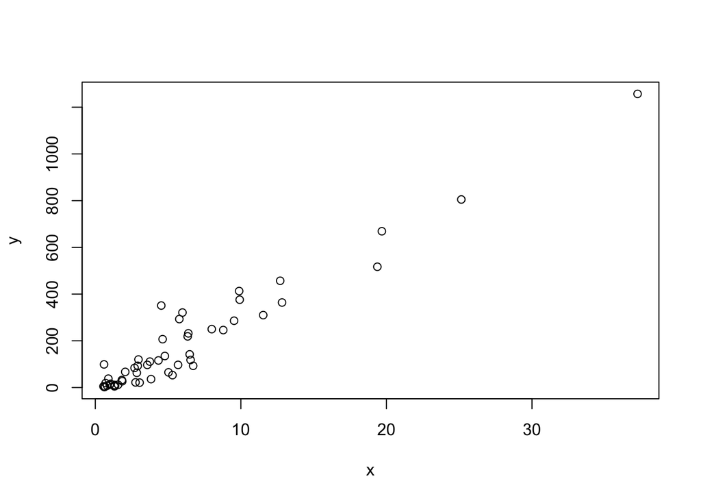

```r
# a simple scatterplot of total murders versus population
x <- murders$population / 10^6
y <- murders$total
plot(x, y)
```

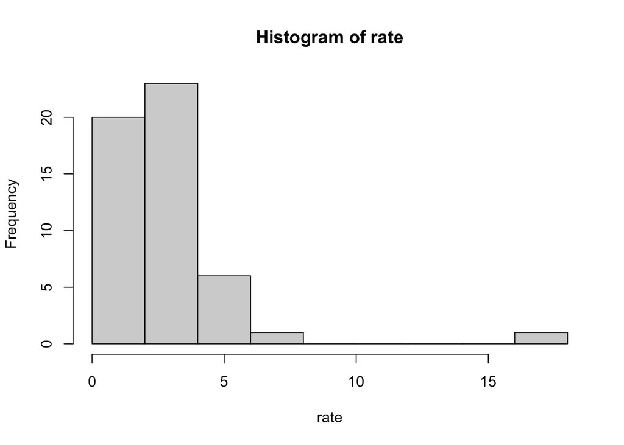

```r
# a histogram of murder rates
hist(rate)
```

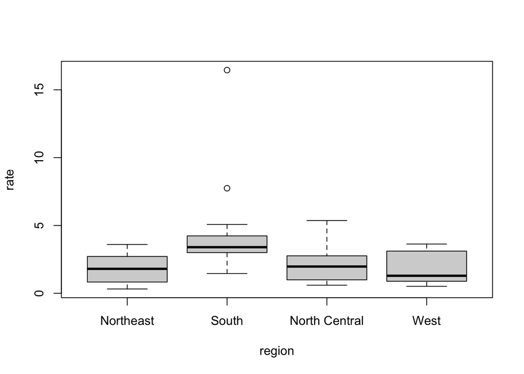

```r
# boxplots of murder rates by region
boxplot(rate~region, data = murders)
```

## Assessment - Basic Plots

1. We made a plot of total murders versus population and noted a strong relationship: not surprisingly, states with larger populations had more murders.

You can run the code in the console to get the plot.

```r
library(dslabs)
data(murders)

population_in_millions <- murders$population/10^6
total_gun_murders <− murders$total

plot(population_in_millions, total_gun_murders)
```

Note that many states have populations below 5 million and are bunched up in the plot. We may gain further insights from making this plot in the log scale.

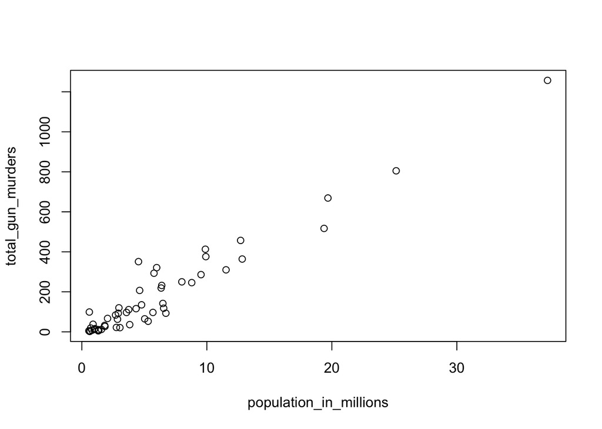

```r
population_in_millions <- murders$population/10^6
total_gun_murders <- murders$total

plot(population_in_millions, total_gun_murders)
```

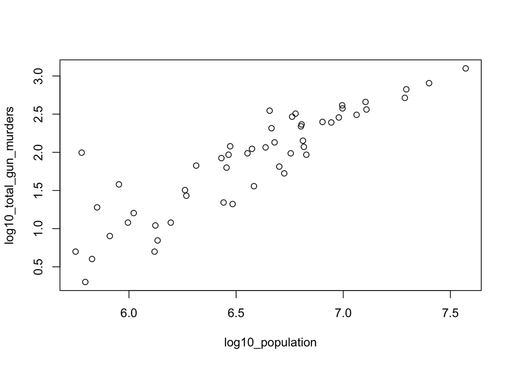

```r
# Transform population using the log10 transformation and save to object log10_population
log10_population <- log10(murders$population)

# Transform total gun murders using log10 transformation and save to object log10_total_gun_murders
log10_total_gun_murders <- log10(total_gun_murders)

# Create a scatterplot with the log scale transformed population and murders
plot(log10_population, log10_total_gun_murders)
```

2. Now we are going to make a histogram.

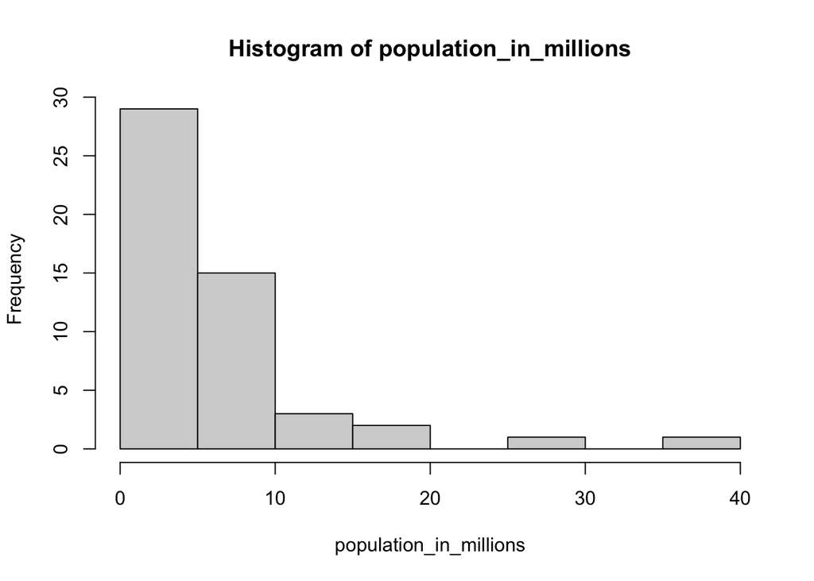

```r
# Store the population in millions and save to population_in_millions
population_in_millions <- murders$population/10^6

# Create a histogram of this variable
hist(population_in_millions)
```

3. Now we are going to make boxplots. Boxplots are useful when we want a summary of several variables or several strata of the same variables. Making too many histograms can become too cumbersome.

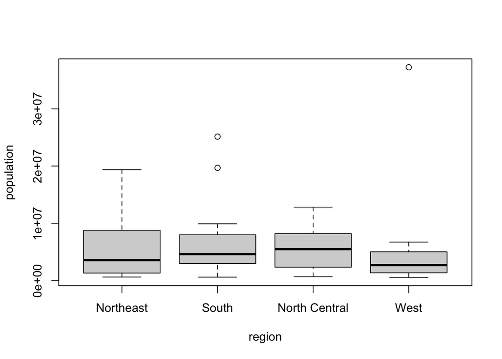

```r
# Create a boxplot of state populations by region for the murders dataset
boxplot(population~region, data = murders)
```

## Section 3 Assessment

```r
data(heights)
options(digits = 3)    # report 3 significant digits for all answers
```

1. First, determine the average height in this dataset. Then create a logical vector `ind` with the indices for those individuals who are above average height.

How many individuals in the dataset are above average height?

```r
ind <- heights$height > mean(heights$height)
sum(ind)
```

```
## [1] 532
```

2. How many individuals in the dataset are above average height and are female?

```r
sum(ind & heights$sex=="Female")
```

```
## [1] 31
```

3. If you use `mean` on a logical (TRUE/FALSE) vector, it returns the proportion of observations that are TRUE.

What proportion of individuals in the dataset are female?

```r
mean(heights$sex == "Female")
```

```
## [1] 0.227
```

4. This question takes you through three steps to determine the sex of the individual with the minimum height.

Determine the minimum height in the `heights` dataset.

```r
min(heights$height)
```

```
## [1] 50
```

Use the `match()` function to determine the index of the individual with the minimum height.

```r
match(50,heights$height)
```

```
## [1] 1032
```

Subset the `sex` column of the dataset by the index above to determine the individual’s sex. `Male`

```r
heights$sex[1032]
```

```
## [1] Male
## Levels: Female Male
```

5. This question takes you through three steps to determine how many of the integer height values between the minimum and maximum heights are not actual heights of individuals in the heights dataset.

Determine the maximum height.

```r
max(heights$height)
```

```
## [1] 82.7
```

Which integer values are between the maximum and minimum heights? For example, if the minimum height is 10.2 and the maximum height is 20.8, your answer should be `x <- 11:20` to capture the integers in between those values. (If either the maximum or minimum height are integers, include those values too.)

Write code to create a vector x that includes the *integers* between the minimum and maximum heights.

```r
x <- 50:82
```

How many of the integers in x are NOT heights in the dataset?

```r
sum(!(x %in% heights$height))
```

```
## [1] 3
```

6. Using the `heights` dataset, create a new column of heights in centimeters named `ht_cm`. Recall that 1 inch = 2.54 centimeters. Save the resulting dataset as `heights2`.

What is the height in centimeters of the 18th individual (index 18)?

```r
heights2 <- mutate(heights, ht_cm = height*2.54)

# Then we subset the new heights2 dataset:

heights2$ht_cm[18]
```

```
## [1] 163
```

What is the mean height in centimeters?

```r
mean(heights2$ht_cm)
```

```
## [1] 174
```

Create a data frame `females` by filtering the `heights2` data to contain only female individuals.

How many females are in the heights2 dataset?

```r
females <- filter(heights2, sex == "Female")
nrow(females)
```

```
## [1] 238
```

What is the mean height of the females in centimeters?

```r
mean(females$ht_cm)
```

```
## [1] 165
```

8. The `olive` dataset in **dslabs** contains composition in percentage of eight fatty acids found in the lipid fraction of 572 Italian olive oils:

```r
data(olive)
head(olive)
```

```
##           region         area palmitic palmitoleic stearic oleic linoleic
## 1 Southern Italy North-Apulia    10.75        0.75    2.26  78.2     6.72
## 2 Southern Italy North-Apulia    10.88        0.73    2.24  77.1     7.81
## 3 Southern Italy North-Apulia     9.11        0.54    2.46  81.1     5.49
## 4 Southern Italy North-Apulia     9.66        0.57    2.40  79.5     6.19
## 5 Southern Italy North-Apulia    10.51        0.67    2.59  77.7     6.72
## 6 Southern Italy North-Apulia     9.11        0.49    2.68  79.2     6.78
##   linolenic arachidic eicosenoic
## 1      0.36      0.60       0.29
## 2      0.31      0.61       0.29
## 3      0.31      0.63       0.29
## 4      0.50      0.78       0.35
## 5      0.50      0.80       0.46
## 6      0.51      0.70       0.44
```

Plot the percent palmitic acid versus palmitoleic acid in a scatterplot. What relationship do you see?

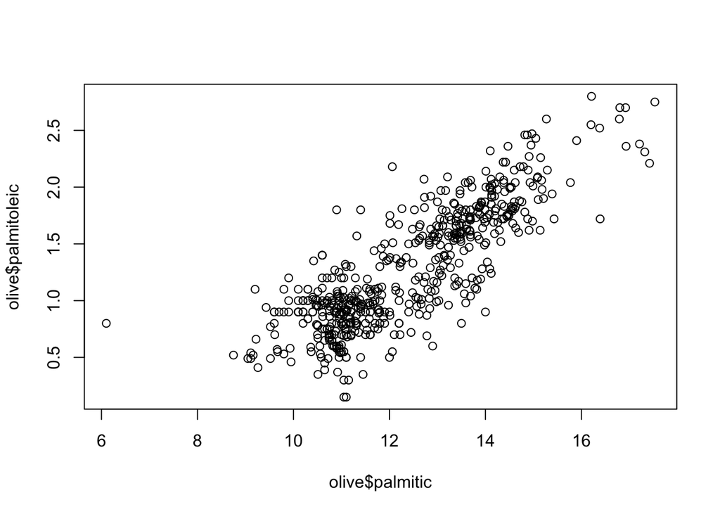

```r
plot(olive$palmitic, olive$palmitoleic)
```

- A. There is no relationship between palmitic and palmitoleic.
- B. There is a positive linear relationship between palmitic and palmitoleic.
- C. There is a negative linear relationship between palmitic and palmitoleic.
- D. There is a positive exponential relationship between palmitic and palmitoleic.
- E. There is a negative exponential relationship between palmitic and palmitoleic.
9. Create a histogram of the percentage of eicosenoic acid in `olive`. Which of the following is true?

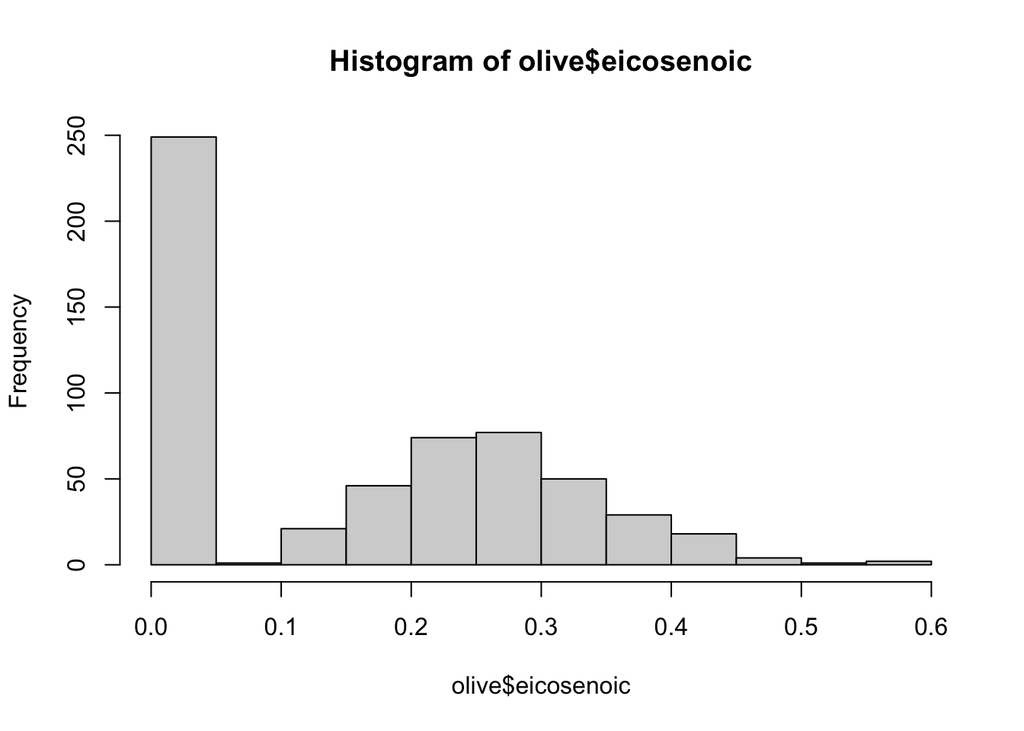

```r
hist(olive$eicosenoic)
```

- A. The most common value of eicosenoic acid is below 0.05%.
- B. The most common value of eicosenoic acid is greater than 0.5%.
- C. The most common value of eicosenoic acid is around 0.3%.
- D. There are equal numbers of olive oils with eicosenoic acid below 0.05% and greater than 0.5%.
10. Make a boxplot of palmitic acid percentage in `olive` with separate distributions for each region.

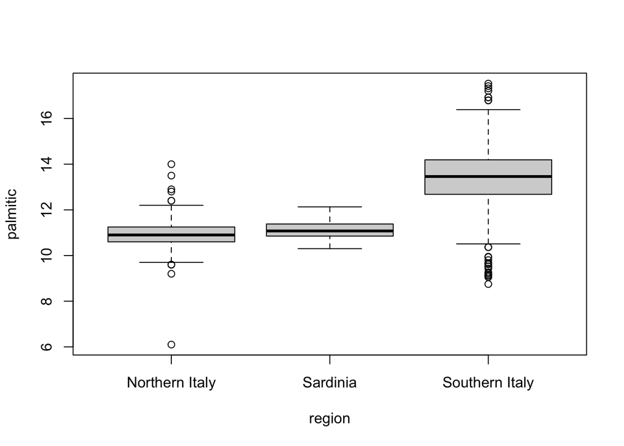

```r
boxplot(palmitic ~ region, data = olive)
```

Which region has the highest median palmitic acid percentage? `Southern Italy`

Which region has the most variable palmitic acid percentage? `Southern Italy`

# Section 4 Overview

Section 4 introduces you to general programming features like ‘if-else’, and ‘for loop’ commands so that you can write your own functions to perform various operations on datasets.

In Section 4.1, you will:

- Understand some of the programming capabilities of R.

In Section 4.2, you will:

- Use basic conditional expressions to perform different operations.
- Check if any or all elements of a logical vector are TRUE.

In Section 4.3, you will:

- Define and call functions to perform various operations.
- Pass arguments to functions, and return variables/objects from functions.

In Section 4.4, you will:

- Use ‘for’ loop to perform repeated operations.
- Articulate in-built functions of R that you could try for yourself.

## Programming Basics - Introduction to Programming in R

The textbook for this section is available [here](https://rafalab.github.io/dsbook/programming-basics.html).

## Basic Conditionals

The textbook for this section is available [here](https://rafalab.github.io/dsbook/programming-basics.html#conditionals).

**Key Points**

- The most common conditional expression in programming is an if-else statement, which has the form “if [condition], perform [expression], else perform [alternative expression]”.
- The `ifelse()` function works similarly to an if-else statement, but it is particularly useful since it works on vectors by examining each element of the vector and returning a corresponding answer accordingly.
- The `any()` function takes a vector of logicals and returns true if any of the entries are true.
- The `all()` function takes a vector of logicals and returns true if all of the entries are true.

*Code*

```r
# an example showing the general structure of an if-else statement
a <- 0
if(a!=0){
  print(1/a)
} else{
  print("No reciprocal for 0.")
}
```

```
## [1] "No reciprocal for 0."
```

```r
# an example that tells us which states, if any, have a murder rate less than 0.5
library(dslabs)
data(murders)
murder_rate <- murders$total / murders$population*100000
ind <- which.min(murder_rate)
if(murder_rate[ind] < 0.5){
  print(murders$state[ind])
} else{
  print("No state has murder rate that low")
}
```

```
## [1] "Vermont"
```

```r
# changing the condition to < 0.25 changes the result
if(murder_rate[ind] < 0.25){
  print(murders$state[ind])
} else{
  print("No state has a murder rate that low.")
}
```

```
## [1] "No state has a murder rate that low."
```

```r
# the ifelse() function works similarly to an if-else conditional
a <- 0
ifelse(a > 0, 1/a, NA)
```

```
## [1] NA
```

```r
# the ifelse() function is particularly useful on vectors
a <- c(0,1,2,-4,5)
result <- ifelse(a > 0, 1/a, NA)

# the ifelse() function is also helpful for replacing missing values
data(na_example)
no_nas <- ifelse(is.na(na_example), 0, na_example)
sum(is.na(no_nas))
```

```
## [1] 0
```

```r
# the any() and all() functions evaluate logical vectors
z <- c(TRUE, TRUE, FALSE)
any(z)
```

```
## [1] TRUE
```

```r
all(z)
```

```
## [1] FALSE
```

## Functions

The textbook for this section is available [here](https://rafalab.github.io/dsbook/programming-basics.html#defining-functions).

**Key points**

- The R function, called `function()` tells R you are about to define a new function.
- Functions are objects, so must be assigned a variable name with the arrow operator.
- The general way to define functions is: (1) decide the function name, which will be an object, (2) type `function()` with your function’s arguments in parentheses, (3) write all the operations inside brackets.
- Variables defined inside a function are not saved in the workspace.

*Code*

```r
# example of defining a function to compute the average of a vector x
avg <- function(x){
  s <- sum(x)
  n <- length(x)
  s/n
}

# we see that the above function and the pre-built R mean() function are identical
x <- 1:100
identical(mean(x), avg(x))
```

```
## [1] TRUE
```

```r
# variables inside a function are not defined in the workspace
s <- 3
avg(1:10)
```

```
## [1] 5.5
```

```r
s
```

```
## [1] 3
```

```r
# the general form of a function
my_function <- function(VARIABLE_NAME){
  perform operations on VARIABLE_NAME and calculate VALUE
  VALUE
}
```

```r
# functions can have multiple arguments as well as default values
avg <- function(x, arithmetic = TRUE){
  n <- length(x)
  ifelse(arithmetic, sum(x)/n, prod(x)^(1/n))
}
```

## For Loops

The textbook for this section is available [here](https://rafalab.github.io/dsbook/programming-basics.html#for-loops).

**Key points**

- For-loops perform the same task over and over while changing the variable. They let us define the range that our variable takes, and then changes the value with each loop and evaluates the expression every time inside the loop.
- The general form of a for-loop is: “For i in [some range], do operations”. This i changes across the range of values and the operations assume i is a value you’re interested in computing on.
- At the end of the loop, the value of i is the last value of the range.

*Code*

```r
# creating a function that computes the sum of integers 1 through n
compute_s_n <- function(n){
  x <- 1:n
  sum(x)
}

# a very simple for-loop
for(i in 1:5){
  print(i)
}
```

```
## [1] 1
## [1] 2
## [1] 3
## [1] 4
## [1] 5
```

```r
# a for-loop for our summation
m <- 25
s_n <- vector(length = m) # create an empty vector
for(n in 1:m){
  s_n[n] <- compute_s_n(n)
}

# creating a plot for our summation function
n <- 1:m
plot(n, s_n)

# a table of values comparing our function to the summation formula
head(data.frame(s_n = s_n, formula = n*(n+1)/2))
```

```
##   s_n formula
## 1   1       1
## 2   3       3
## 3   6       6
## 4  10      10
## 5  15      15
## 6  21      21
```

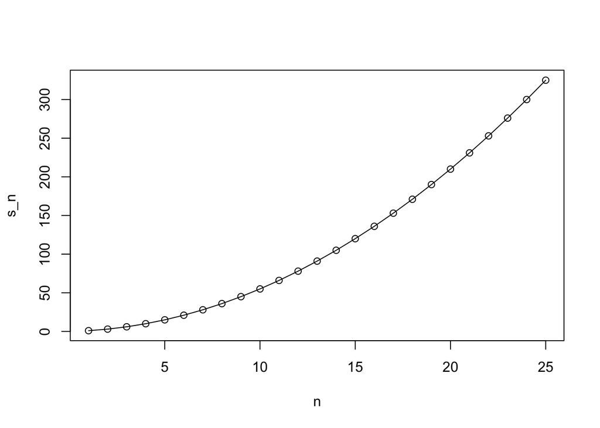

```r
# overlaying our function with the summation formula
plot(n, s_n)
lines(n, n*(n+1)/2)
```

## Assessment - Programming Basics

1. What will this conditional expression return?

```r
x <- c(1,2,-3,4)
if(all(x>0)){
print("All Postives")
} else{
print("Not all positives")
}
```

```
## [1] "Not all positives"
```

- A. All Positives
- B. Not All Positives
- C. N/A
- D. None of the above
2. Which of the following expressions is always `FALSE` when at least one entry of a logical vector x is `TRUE`?
- A. all(x)
- B. any(x)
- C. any(!x)
- D. all(!x)
3. The function `nchar` tells you how many characters long a character vector is.

For example:

```r
char_len <- nchar(murders$state)
head(char_len)
```

The function `ifelse` is useful because you convert a vector of logicals into something else. For example, some datasets use the number -999 to denote NA. A bad practice! You can convert the -999 in a vector to NA using the following `ifelse` call:

```r
x <- c(2, 3, -999, 1, 4, 5, -999, 3, 2, 9)
ifelse(x == -999, NA, x)
```

If the entry is -999 it returns NA, otherwise it returns the entry.

```r
# Assign the state abbreviation when the state name is longer than 8 characters
char_len <- nchar(murders$state)
new_names <- ifelse(char_len > 8, murders$abb, murders$state)
```

4. You will encounter situations in which the function you need does not already exist. R permits you to write your own.

Let’s practice one such situation, in which you first need to define the function to be used. The functions you define can have multiple arguments as well as default values.

The last value in the function, in this case that stored in `y`, gets returned.

If you run the code above R does not show anything. This means you defined the function. You can test it out like this:

```r
my_func(5)
```

```r
# Create function called `sum_n`
sum_n <- function(n){
    x <- 1:n
    sum(x)
}

# Use the function to determine the sum of integers from 1 to 5000
sum_n(5000)
```

```
## [1] 12502500
```

5. We will make another function for this exercise. We will define a function `altman_plot` that takes two arguments `x` and `y` and plots the difference `y-x` in the y-axis against the sum `x+y` in the x-axis.

You can define functions with as many variables as you want. For example, here we need at least two, `x` and `y`. The following function plots log transformed values:

```r
log_plot <- function(x, y){
    plot(log10(x), log10(y))
}
```

This function does not return anything. It just makes a plot.

```r
# Create `altman_plot`
altman_plot <- function(x, y) {
  plot(x+y, y-x)
}
```

6. Lexical scoping is a convention used by many languages that determine when an object is available by its name.

When you run the code below you will see which `x` is available at different points in the code.

```r
x <- 8
my_func <- function(y){
    x <- 9
    print(x)
    y + x
}
my_func(x)
print(x)
```

Note that when we define `x` as 9, this is inside the function, but it is 8 after you run the function. The `x` changed inside the function but not outside.

```r
# Run this code
x <- 3
    my_func <- function(y){
    x <- 5
    y+5
}

# Print the value of x
x <- 3
my_func <- function(y){
    x <- 5
    y
    print(x)
}
my_func(x)
```

```
## [1] 5
```

```r
print(x)
```

```
## [1] 3
```

7. In the next exercise we are going to write a for-loop. In that for-loop we are going to call a function. We define that function here.

```r
# Here is an example of a function that adds numbers from 1 to n
example_func <- function(n){
    x <- 1:n
    sum(x)
}

# Here is the sum of the first 100 numbers
example_func(100)
```

```
## [1] 5050
```

```r
# Write a function compute_s_n with argument n that for any given n computes the sum of 1 + 2^2 + ...+ n^2
compute_s_n <- function(n){
    x <- 1:n
    sum(x^2)
}

# Report the value of the sum when n=10
compute_s_n(10)
```

```
## [1] 385
```

8. Now we are going to compute the sum of the squares for several values of *n*. We will use a for-loop for this.

Here is an example of a for-loop:

```r
results <- vector("numeric", 10)
n <- 10
for(i in 1:n){
    x <- 1:i
    results[i] <- sum(x)
}
```

Note that we start with a call to `vector` which constructs an empty vector that we will fill while the loop runs.

```r
# Define a function and store it in `compute_s_n`
compute_s_n <- function(n){
  x <- 1:n
  sum(x^2)
}

# Create a vector for storing results
s_n <- vector("numeric", 25)

# write a for-loop to store the results in s_n
for(n in 1:length(s_n)){
  s_n[n] <- compute_s_n(n)
}
```

9. If we do the math, we can show that $S_n = 1^2+2^2+3^2+⋯+n^2 = n(n+1)(2n+1)/6$

We have already computed the values of $S_n$ from 1 to 25 using a for loop.

If the formula is correct then a plot of $S_n$ versus *n* should look cubic.

Let’s make this plot.

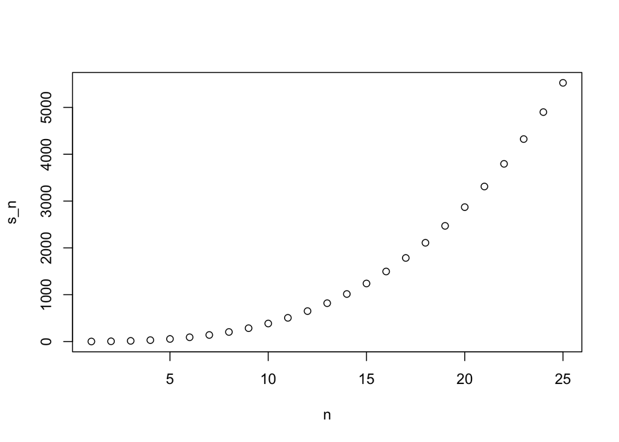

```r
# Define the function
compute_s_n <- function(n){
  x <- 1:n
  sum(x^2)
}

# Define the vector of n
n <- 1:25

# Define the vector to store data
s_n <- vector("numeric", 25)
for(i in n){
  s_n[i] <- compute_s_n(i)
}

#  Create the plot
plot(n,s_n)
```

10. Now let’s actually check if we get the exact same answer.

```r
# Define the function
compute_s_n <- function(n){
  x <- 1:n
  sum(x^2)
}

# Define the vector of n
n <- 1:25

# Define the vector to store data
s_n <- vector("numeric", 25)
for(i in n){
  s_n[i] <- compute_s_n(i)
}

# Check that s_n is identical to the formula given in the instructions.
identical(s_n,(n*(n+1)*(2*n+1))/6)
```

```
## [1] TRUE
```

## Section 4 Assessment

1. Load the **heights** dataset from dslabs:

```r
library(dslabs)
data(heights)
```

Write an `ifelse` statement that returns 1 if the sex is Female and 2 if the sex is Male.

What is the sum of the resulting vector?

```r
sum(ifelse(heights$sex == "Female", 1, 2))
```

```
## [1] 1862
```

2. Write an `ifelse` statement that takes the height column and returns the height if it is greater than 72 inches and returns 0 otherwise.

What is the mean of the resulting vector?

```r
mean(ifelse(heights$height > 72, heights$height, 0))
```

```
## [1] 9.65
```

3. Write a function `inches_to_ft` that takes a number of inches x and returns the number of feet. One foot equals 12 inches.

What is `inches_to_ft(144)`?

```r
inches_to_ft <- function(x){x/12}
inches_to_ft(144)
```

```
## [1] 12
```

How many individuals in the heights dataset have a height less than 5 feet?

```r
sum(inches_to_ft(heights$height) < 5)
```

```
## [1] 20
```

4. Which of the following are TRUE?

Select ALL that apply.

- A. any(TRUE, TRUE, TRUE)
- B. any(TRUE, TRUE, FALSE)
- C. any(TRUE, FALSE, FALSE)
- D. any(FALSE, FALSE, FALSE)
- E. all(TRUE, TRUE, TRUE)
- F. all(TRUE, TRUE, FALSE)
- G. all(TRUE, FALSE, FALSE)
- H. all(FALSE, FALSE, FALSE)
5. Given an integer x, the factorial of x is called x! and is the product of all integers up to and including x. The `factorial()` function computes factorials in R. For example, `factorial(4)` returns $4! = 4 × 3 × 2 × 1 = 24$.

Complete the code below to generate a vector of length m where the first entry is 1!, the second entry is 2!, and so on up to m!.

```r
# define a vector of length m
m <- 10
f_n <- vector(length = m)

# make a vector of factorials
for(n in 1:m){
f_n[n] <- factorial(n)
}

# inspect f_n
f_n
```

```
##  [1]       1       2       6      24     120     720    5040   40320  362880
## [10] 3628800
```

- A. function(n)
- B. if(n < m)
- C. for(n in 1:m)
- D. function(m,n)
- E. if(m < n)
- F. for(m in 1:n)